# Part A: Batch Translation Evaluation

**Platform:** Kaggle GPU T4 (15 GB VRAM)  
**Dataset:** FLoRes-200 `eng_Latn -> tam_Taml`, first 100 sentences (devtest split)  
**Metric:** sacreBLEU (corpus-level + sentence-level)

## Pipeline Overview

This notebook is **Part A** of a three-part evaluation pipeline:

| Part | Focus | Output |
| --- | --- | --- |
| A (this) | Run 5 translation models on FLoRes-200 | `sacrebleu_results.csv` |
| B | Token-level EDA: expansion ratios, fragmentation | `token_counts.csv`, `engineered_features.csv` |
| C | Indic vocab coverage, memory footprint, chars/token | plots |

## Model Selection Rationale

Five models were chosen to cover three distinct training philosophies and a wide parameter range:

| Model | Parameters | Training Philosophy | Role in Evaluation |
| --- | --- | --- | --- |
| `Helsinki-NLP/opus-mt-en-dra` | ~74 M | Multilingual EN→Dravidian (ta/kn/ml/te); requires `>>tam<<` prefix | Fast baseline; smallest vocab |
| `google/mt5-base` | 580 M | Masked LM pre-training on 101 languages | Tokenizer reference only; not an MT model |
| `facebook/nllb-200-distilled-600M` | 600 M | Massively multilingual (200 languages) | Mid-size multilingual benchmark |
| `ai4bharat/indictrans2-en-indic-1B` | 1 B | Indic-dedicated; trained on 22 Indian languages | Expected best for Tamil script fidelity |
| `google/madlad400-3b-mt` | 3 B | 400-language multilingual translation | Largest model; upper-bound reference |

> **mT5 note:** mT5 is not fine-tuned for translation and produces no valid Tamil output. It is included solely so Parts B and C can compare its tokenizer vocabulary against the MT models.

## Why FLoRes-200?

FLoRes-200 is the standard benchmark for low-resource and Indic translation. It provides professionally translated Tamil references (not machine-generated), making it suitable for BLEU evaluation. The first 100 sentences of the `devtest` split are used to keep GPU runtime under 90 minutes on a T4.

```python
# ── GPU compatibility check ────────────────────────────────────────────────────
# PyTorch 2.2+ requires CUDA compute capability >= sm_70.
# Tesla P100 = sm_60 → incompatible with the Kaggle default PyTorch (2.10).
# Tesla T4   = sm_75 → compatible. Switch the accelerator if you see a warning.
#
# HOW TO USE:
#   If this cell prints a STOP message, go to:
#   Settings (right panel) → Accelerator → GPU T4 x1 → Save
#   Then restart the kernel and Run All.
import torch, sys

print(f"Python : {sys.version.split()[0]}")
print(f"PyTorch: {torch.__version__}")
print(f"CUDA   : {torch.cuda.is_available()}")

if torch.cuda.is_available():
    name = torch.cuda.get_device_name(0)
    sm_major, sm_minor = torch.cuda.get_device_capability(0)
    vram = round(torch.cuda.get_device_properties(0).total_memory / 1e9, 1)
    print(f"GPU    : {name}  (sm_{sm_major}{sm_minor})  |  VRAM: {vram} GB")

    if sm_major < 7:
        print()
        print("=" * 65)
        print("STOP: This GPU (sm_60) is not supported by PyTorch 2.2+.")
        print("PyTorch 2.1.x (last sm_60 release) requires Python ≤ 3.11,")
        print("but Kaggle uses Python 3.12 — so a downgrade is impossible.")
        print()
        print("Fix: Settings → Accelerator → GPU T4 x1 → Save")
        print("     Then restart the kernel and Run All.")
        print("=" * 65)
        raise SystemExit("Switch GPU to T4 before continuing.")
    else:
        print("GPU is compatible with PyTorch 2.2+. Proceed.")
```

```
Python : 3.12.12
PyTorch: 2.10.0+cu128
CUDA   : True
GPU    : Tesla T4  (sm_75)  |  VRAM: 15.6 GB
GPU is compatible with PyTorch 2.2+. Proceed.
```

## 1. Environment Check

Confirm GPU availability before loading any models. All five models require CUDA; MADLAD-400 (3 B, ~6 GB fp16) is the most VRAM-intensive and must be the last model loaded. The `clear_memory()` utility is called after every model to release VRAM before loading the next.

```python
# Cell 0 -- Runtime check + memory utility
import subprocess, sys, os, gc, torch

print("Python :", sys.version)
print("PyTorch:", torch.__version__)
print("CUDA   :", torch.cuda.is_available())
if torch.cuda.is_available():
    print("GPU    :", torch.cuda.get_device_name(0))
    print("VRAM   :", round(torch.cuda.get_device_properties(0).total_memory / 1e9, 1), "GB")

DEVICE = "cuda" if torch.cuda.is_available() else "cpu"

os.makedirs("plots", exist_ok=True)

def clear_memory():
    """Release GPU/CPU memory between model loads."""
    gc.collect()
    if torch.cuda.is_available():
        torch.cuda.empty_cache()
```

```
Python : 3.12.12 (main, Oct 10 2025, 08:52:57) [GCC 11.4.0]
PyTorch: 2.10.0+cu128
CUDA   : True
GPU    : Tesla T4
VRAM   : 15.6 GB
```

## 2. Global Visual Theme

A single color palette and Matplotlib configuration is defined here and reused across all charts in this notebook and Parts B and C. Consistent colors per model make it easy to compare models visually across all three parts without a legend lookup.

```python
# Cell 1 -- Global visual theme
import matplotlib.pyplot as plt
import seaborn as sns

PALETTE = ["#2E86AB", "#A23B72", "#F18F01", "#C73E1D", "#3B1F2B"]
MODEL_COLORS = {
    "IndicTrans2" : "#2E86AB",   # blue   -- best Indic model
    "NLLB-200"    : "#A23B72",   # purple -- Meta multilingual
    "mT5"         : "#F18F01",   # orange -- tokenization reference only
    "Helsinki"    : "#C73E1D",   # red    -- smallest, fastest
    "MADLAD"      : "#3B1F2B",   # dark   -- Google 3B
}
sns.set_theme(style="whitegrid", font_scale=1.1)
plt.rcParams.update({
    "figure.dpi"          : 150,
    "figure.facecolor"    : "white",
    "axes.spines.top"     : False,
    "axes.spines.right"   : False,
    "font.family"         : "DejaVu Sans",
})
```

## 3. Install Dependencies

Kaggle kernels start from a base image that already includes PyTorch and most data science libraries. The only packages that need explicit installation are:

- `transformers==4.53.2` — **pinned version** required for `ai4bharat/indictrans2-en-indic-1B`. Versions ≥ 4.54 break `IndicTransForConditionalGeneration.tie_weights()` (AI4Bharat issue #128). Do not change this pin.
- `sacrebleu` — standardized BLEU evaluation with Unicode tokenization (SacreBLEU v2)
- `sacremoses` — Moses tokenizer used internally by MarianMT (Helsinki)
- `IndicTransToolkit` — IndicProcessor for IndicTrans2 pre/post-processing. Installed from VarunGumma's GitHub fork (maintained, compatible with transformers 4.53.2).

Internet must be **On** in the kernel settings for the `pip install` and model downloads to succeed.

```python
# Cell 2 -- Install dependencies
# Pin transformers==4.53.2 — last confirmed working version with ai4bharat/indictrans2-en-indic-1B.
# Versions >=4.54 break IndicTransForConditionalGeneration.tie_weights() (AI4Bharat issue #128).
!pip install -q transformers==4.53.2 sacrebleu>=2.3.1 datasets>=2.14.0 \
    sentencepiece>=0.1.99 accelerate>=0.24.0 sacremoses
!pip install -q git+https://github.com/VarunGumma/IndicTransToolkit.git
```

```
  Installing build dependencies ... done
  Getting requirements to build wheel ... done
  Preparing metadata (pyproject.toml) ... done
   ━━━━━━━━━━━━━━━━━━━━━━━━━━━━━━━━━━━━━━━━ 53.8/53.8 kB 2.1 MB/s eta 0:00:00
   ━━━━━━━━━━━━━━━━━━━━━━━━━━━━━━━━━━━━━━━━ 7.7/7.7 MB 67.9 MB/s eta 0:00:00:00:010:01
   ━━━━━━━━━━━━━━━━━━━━━━━━━━━━━━━━━━━━━━━━ 121.1/121.1 kB 8.8 MB/s eta 0:00:00
```

## 4. Imports

```python
# Cell 3 -- Imports
import pandas as pd
import numpy as np
import sacrebleu
from datasets import load_dataset
from transformers import (
    MarianMTModel, MarianTokenizer,
    MT5ForConditionalGeneration, T5Tokenizer,
    NllbTokenizer, AutoModelForSeq2SeqLM,
    AutoTokenizer,
)
from tqdm.auto import tqdm
from IndicTransToolkit import IndicProcessor

print("All imports OK")
```

[output not shown]

```
All imports OK
```

## 5. Load FLoRes-200 Dataset

FLoRes-200 is loaded directly from HuggingFace -- no manual download required. The `devtest` split provides 1,012 sentence pairs; we take the first 100 to keep the GPU run under 90 minutes while still generating statistically meaningful BLEU scores.

**Key detection:** Different dataset versions use slightly different column names (`sentence_eng_Latn` vs `sentence`). The cell detects the correct key at runtime to avoid `KeyError` on future dataset updates.

```python
# Cell 4 -- Load FLoRes+ dataset
from datasets import load_dataset
from kaggle_secrets import UserSecretsClient
from huggingface_hub import login
import pandas as pd

secrets = UserSecretsClient()
hf_token = secrets.get_secret("HF_TOKEN")
login(token=hf_token)

# Load English and Tamil as separate configs (flores_plus structure)
eng = load_dataset("openlanguagedata/flores_plus", "eng_Latn", split="devtest", token=hf_token)
tam = load_dataset("openlanguagedata/flores_plus", "tam_Taml", split="devtest", token=hf_token)

# Select first 100 — IDs are aligned across languages
eng_100 = eng.select(range(100))
tam_100 = tam.select(range(100))

source_sentences = [ex["text"] for ex in eng_100]
reference_tamil  = [ex["text"] for ex in tam_100]

df = pd.DataFrame({"source_english": source_sentences, "reference_tamil": reference_tamil})
print(f"Loaded {len(df)} sentence pairs")
df.head(3)
```

```
README.md: 0.00B [00:00, ?B/s]
```

```
eng_Latn.jsonl: 0.00B [00:00, ?B/s]
```

```
eng_Latn.jsonl: 0.00B [00:00, ?B/s]
```

```
tam_Taml.jsonl: 0.00B [00:00, ?B/s]
```

```
tam_Taml.jsonl: 0.00B [00:00, ?B/s]
```

```
Loaded 100 sentence pairs
```

|  | source_english | reference_tamil |
| --- | --- | --- |
| 0 | "We now have 4-month-old mice that are non-dia... | """எங்களிடம் இப்போது 4-மாத-வயதுடைய எலி ஒன்று ... |
| 1 | Dr. Ehud Ur, professor of medicine at Dalhousi... | ஹாலிஃபாக்ஸில் உள்ள டல்ஹெளசி பல்கலைக்கழகத்தின் ... |
| 2 | Like some other experts, he is skeptical about... | பிற வல்லுனர்கள் போலவே அவரும், ஏற்கனவே டைப் 1 இ... |

## 6. Translation Functions

Each model has its own translation function to handle its unique API requirements:

| Model | Special Requirement | Why |
| --- | --- | --- |
| Helsinki | `>>tam<<` prefix on every source sentence | `opus-mt-en-dra` is multilingual (EN→Tamil/Kannada/Malayalam/Telugu); without this prefix the output language is undefined |
| mT5 | Tokenize only, no generation | Not fine-tuned for translation |
| NLLB-200 | `forced_bos_token_id` set to `tam_Taml` token | NLLB needs an explicit target-language BOS token to select the output language |
| IndicTrans2 | `IndicProcessor` pre/post-processing; no `src_lang` in tokenizer, no `forced_bos_token_id` | Target language is set by `IndicProcessor.preprocess_batch`; the tokenizer takes the preprocessed text directly |
| MADLAD-400 | `<2ta>` prefix prepended to every sentence | Task prefix selects the target language in MADLAD's T5-style format |

All MT functions use `num_beams=4` for beam search. `max_length=256` / `max_new_tokens=256` is sufficient for Tamil output from 100-token English inputs given the ~1.5× expansion typical of Tamil.

```python
# Cell 5 -- Translation functions (one per model)

def translate_helsinki(texts, tokenizer, model, batch_size=16):
    """
    Helsinki-NLP/opus-mt-en-dra
    MarianMT ~74M params | SentencePiece 32k vocab
    Multilingual EN→Dravidian (Tamil/Kannada/Malayalam/Telugu).
    Requires >>tam<< language token prefix to select Tamil as target.
    """
    translations = []
    prefixed = [f">>tam<< {t}" for t in texts]
    for i in tqdm(range(0, len(prefixed), batch_size), desc="Helsinki"):
        batch = prefixed[i:i+batch_size]
        inputs = tokenizer(batch, return_tensors="pt", padding=True,
                           truncation=True, max_length=256).to(DEVICE)
        with torch.no_grad():
            outputs = model.generate(**inputs, max_new_tokens=256, num_beams=4)
        decoded = tokenizer.batch_decode(outputs, skip_special_tokens=True)
        translations.extend(decoded)
    return translations


def translate_mt5(texts, tokenizer, batch_size=16):
    """
    google/mt5-base
    mT5 ~580M params | SentencePiece 250k vocab
    NOT a translation model -- included for tokenization comparison only.
    Tokenizer output is used in Part B; no BLEU score is computed.
    """
    tokens_list = []
    for i in tqdm(range(0, len(texts), batch_size), desc="mT5 tokenize"):
        batch = texts[i:i+batch_size]
        enc = tokenizer(batch, return_tensors="pt", padding=True,
                        truncation=True, max_length=256)
        tokens_list.extend([
            tokenizer.convert_ids_to_tokens(ids.tolist())
            for ids in enc["input_ids"]
        ])
    return [" ".join(t) for t in tokens_list]


def translate_nllb(texts, tokenizer, model, batch_size=8):
    """
    facebook/nllb-200-distilled-600M
    NLLB-200 ~600M params | SentencePiece 256k vocab
    Meta multilingual model; supports 200 languages.
    """
    translations = []
    for i in tqdm(range(0, len(texts), batch_size), desc="NLLB-200"):
        batch = texts[i:i+batch_size]
        inputs = tokenizer(batch, return_tensors="pt", padding=True,
                           truncation=True, max_length=256).to(DEVICE)
        with torch.no_grad():
            outputs = model.generate(
                **inputs,
                forced_bos_token_id=tokenizer.convert_tokens_to_ids("tam_Taml"),
                max_new_tokens=256, num_beams=4
            )
        decoded = tokenizer.batch_decode(outputs, skip_special_tokens=True)
        translations.extend(decoded)
    return translations


def translate_indictrans2(texts, tokenizer, model, ip, batch_size=8):
    """
    ai4bharat/indictrans2-en-indic-1B
    IndicTrans2 ~1B params | Indic SentencePiece 32k vocab
    Target language set by IndicProcessor.preprocess_batch -- no forced_bos_token_id needed.
    """
    translations = []
    for i in tqdm(range(0, len(texts), batch_size), desc="IndicTrans2"):
        batch = texts[i:i+batch_size]
        batch_preprocessed = ip.preprocess_batch(
            batch, src_lang="eng_Latn", tgt_lang="tam_Taml"
        )
        inputs = tokenizer(
            batch_preprocessed,
            truncation=True,
            padding="longest",
            return_tensors="pt",
            return_attention_mask=True,
        ).to(DEVICE)
        with torch.no_grad():
            outputs = model.generate(
                **inputs,
                use_cache=True,
                min_length=0,
                max_length=256,
                num_beams=4,
                num_return_sequences=1,
            )
        decoded = tokenizer.batch_decode(
            outputs,
            skip_special_tokens=True,
            clean_up_tokenization_spaces=True,
        )
        postprocessed = ip.postprocess_batch(decoded, lang="tam_Taml")
        translations.extend(postprocessed)
    return translations


def translate_madlad(texts, tokenizer, model, batch_size=8):
    """
    google/madlad400-3b-mt
    MADLAD-400 ~3B params | SentencePiece 256k vocab
    Google multilingual model; requires <2ta> task prefix for Tamil.
    repetition_penalty + no_repeat_ngram_size prevent phrase-loop artifacts
    that MADLAD exhibits on longer sentences without these constraints.
    """
    translations = []
    prefixed = [f"<2ta> {t}" for t in texts]   # CRITICAL -- do not remove this prefix
    for i in tqdm(range(0, len(prefixed), batch_size), desc="MADLAD"):
        batch = prefixed[i:i+batch_size]
        inputs = tokenizer(batch, return_tensors="pt", padding=True,
                           truncation=True, max_length=256).to(DEVICE)
        with torch.no_grad():
            outputs = model.generate(
                **inputs,
                max_new_tokens=256,
                num_beams=4,
                no_repeat_ngram_size=3,
                repetition_penalty=1.2,
            )
        decoded = tokenizer.batch_decode(outputs, skip_special_tokens=True)
        translations.extend(decoded)
    return translations


print("Translation functions defined")
```

```
Translation functions defined
```

## 7. Sequential Translation Pipeline

**Why sequential loading?**  
The T4 has 15 GB VRAM. MADLAD-400 alone requires ~6 GB in fp16. Loading all five models simultaneously would exceed VRAM. Instead, each model is:

1. Loaded onto GPU
2. Used to translate all 100 sentences
3. Deleted (`del`) and `clear_memory()` called to free VRAM

**fp16 precision:** NLLB-200, IndicTrans2, and MADLAD are loaded with `torch_dtype=torch.float16` to halve their VRAM footprint with negligible quality loss on modern hardware.

**`device_map` not used:** `device_map="auto"` can split model layers across CPU+GPU unpredictably on a single-GPU machine. Explicit `.to(DEVICE)` gives deterministic placement.

```python
# Cell 6 -- Sequential translation (load -> translate -> clear)
all_translations = {}

# --- Helsinki ---
print("\n[1/5] Helsinki-NLP/opus-mt-en-dra")
tok = MarianTokenizer.from_pretrained("Helsinki-NLP/opus-mt-en-dra")
mod = MarianMTModel.from_pretrained("Helsinki-NLP/opus-mt-en-dra").to(DEVICE)
all_translations["Helsinki"] = translate_helsinki(source_sentences, tok, mod)
del tok, mod; clear_memory()

# --- mT5 (tokenization only) ---
print("\n[2/5] google/mt5-base  (tokenization reference -- no translation)")
tok = T5Tokenizer.from_pretrained("google/mt5-base")
all_translations["mT5"] = translate_mt5(source_sentences, tok)
del tok; clear_memory()

# --- NLLB-200 ---
print("\n[3/5] facebook/nllb-200-distilled-600M")
tok = NllbTokenizer.from_pretrained("facebook/nllb-200-distilled-600M",
                                    src_lang="eng_Latn")
mod = AutoModelForSeq2SeqLM.from_pretrained(
    "facebook/nllb-200-distilled-600M",
    torch_dtype=torch.float16,
).to(DEVICE)
all_translations["NLLB-200"] = translate_nllb(source_sentences, tok, mod)
del tok, mod; clear_memory()

# --- IndicTrans2 ---
print("\n[4/5] ai4bharat/indictrans2-en-indic-1B")
ip  = IndicProcessor(inference=True)
tok = AutoTokenizer.from_pretrained(
    "ai4bharat/indictrans2-en-indic-1B", trust_remote_code=True)
mod = AutoModelForSeq2SeqLM.from_pretrained(
    "ai4bharat/indictrans2-en-indic-1B",
    trust_remote_code=True,
    torch_dtype=torch.float16,
).to(DEVICE)
all_translations["IndicTrans2"] = translate_indictrans2(source_sentences, tok, mod, ip)
del tok, mod, ip; clear_memory()

# --- MADLAD-400 ---
print("\n[5/5] google/madlad400-3b-mt")
tok = AutoTokenizer.from_pretrained("google/madlad400-3b-mt")
mod = AutoModelForSeq2SeqLM.from_pretrained(
    "google/madlad400-3b-mt",
    torch_dtype=torch.float16,
).to(DEVICE)   # explicit .to(DEVICE), not device_map="auto"
all_translations["MADLAD"] = translate_madlad(source_sentences, tok, mod)
del tok, mod; clear_memory()

print("\nAll models done. Keys:", list(all_translations.keys()))
```

```
[1/5] Helsinki-NLP/opus-mt-en-dra
```

```
vocab.json: 0.00B [00:00, ?B/s]
```

```
config.json: 0.00B [00:00, ?B/s]
```

```
[2/5] google/mt5-base  (tokenization reference -- no translation)
```

```
You are using the default legacy behaviour of the <class 'transformers.models.t5.tokenization_t5.T5Tokenizer'>. This is expected, and simply means that the `legacy` (previous) behavior will be used so nothing changes for you. If you want to use the new behaviour, set `legacy=False`. This should only…
```

```
[3/5] facebook/nllb-200-distilled-600M
```

```
special_tokens_map.json: 0.00B [00:00, ?B/s]
```

```
[4/5] ai4bharat/indictrans2-en-indic-1B
```

```
tokenizer_config.json: 0.00B [00:00, ?B/s]
```

```
tokenization_indictrans.py: 0.00B [00:00, ?B/s]
```

```
A new version of the following files was downloaded from https://huggingface.co/ai4bharat/indictrans2-en-indic-1B:
- tokenization_indictrans.py
. Make sure to double-check they do not contain any added malicious code. To avoid downloading new versions of the code file, you can pin a revision.
```

```
dict.SRC.json: 0.00B [00:00, ?B/s]
```

```
dict.TGT.json: 0.00B [00:00, ?B/s]
```

```
config.json: 0.00B [00:00, ?B/s]
```

```
configuration_indictrans.py: 0.00B [00:00, ?B/s]
```

```
A new version of the following files was downloaded from https://huggingface.co/ai4bharat/indictrans2-en-indic-1B:
- configuration_indictrans.py
. Make sure to double-check they do not contain any added malicious code. To avoid downloading new versions of the code file, you can pin a revision.
```

```
modeling_indictrans.py: 0.00B [00:00, ?B/s]
```

```
A new version of the following files was downloaded from https://huggingface.co/ai4bharat/indictrans2-en-indic-1B:
- modeling_indictrans.py
. Make sure to double-check they do not contain any added malicious code. To avoid downloading new versions of the code file, you can pin a revision.
```

```
[5/5] google/madlad400-3b-mt
```

```
All models done. Keys: ['Helsinki', 'mT5', 'NLLB-200', 'IndicTrans2', 'MADLAD']
```

## 8. Save Results

`sacrebleu_results.csv` is the primary output file consumed by Parts B and C. It stores:

- `source_english` / `reference_tamil` -- the original FLoRes-200 pairs
- `pred_<model>` -- raw translation output for all 5 models
- `bleu_<model>` -- sentence-level BLEU score for the 4 MT models (mT5 excluded)

Sentence-level BLEU is computed alongside corpus BLEU so Part B can use it as a per-sentence quality signal when plotting feature correlations.

```python
# Cell 7 -- Save results CSV
bleu_models = ["Helsinki", "NLLB-200", "IndicTrans2", "MADLAD"]
all_models  = ["Helsinki", "mT5", "NLLB-200", "IndicTrans2", "MADLAD"]

df_results = df.copy()
for model_name in all_models:
    df_results[f"pred_{model_name}"] = all_translations[model_name]

for model_name in bleu_models:
    df_results[f"bleu_{model_name}"] = df_results.apply(
        lambda row, m=model_name: sacrebleu.sentence_bleu(
            str(row[f"pred_{m}"]), [str(row["reference_tamil"])]).score,
        axis=1
    )

df_results.to_csv("sacrebleu_results.csv", index=False)

# Also save translation_outputs.csv (source + reference + predictions only)
trans_cols = ["source_english", "reference_tamil"] + [f"pred_{m}" for m in all_models]
df_results[trans_cols].to_csv("translation_outputs.csv", index=False)

print("Saved sacrebleu_results.csv and translation_outputs.csv")
df_results.head(3)
```

```
Saved sacrebleu_results.csv and translation_outputs.csv
```

|  | source_english | reference_tamil | pred_Helsinki | pred_mT5 | pred_NLLB-200 | pred_IndicTrans2 | pred_MADLAD | bleu_Helsinki | bleu_NLLB-200 | bleu_IndicTrans2 | bleu_MADLAD |
| --- | --- | --- | --- | --- | --- | --- | --- | --- | --- | --- | --- |
| 0 | "We now have 4-month-old mice that are non-dia... | """எங்களிடம் இப்போது 4-மாத-வயதுடைய எலி ஒன்று ... | "நமக்கு 4 மாத வயது மூட்டுகள் உள்ளன. | ▁" We ▁now ▁have ▁4- month - old ▁ mice ▁that ... | "நாங்கள் இப்போது 4 மாத வயதுடைய எலிகள் உள்ளன, அ... | "இப்போது எங்களிடம் 4 மாத வயது எலிகள் உள்ளன, அவ... | "நாங்கள் இப்போது4மாத வயதான சுறாக்களைக் கொண்டுள... | 0.766029 | 17.414675 | 21.207851 | 20.158991 |
| 1 | Dr. Ehud Ur, professor of medicine at Dalhousi... | ஹாலிஃபாக்ஸில் உள்ள டல்ஹெளசி பல்கலைக்கழகத்தின் ... | இந்த ஆராய்ச்சி இன்னும் ஆரம்பத்திலேயே இருக்கிறத... | ▁Dr . ▁E hud ▁Ur , ▁professor ▁of ▁medicine ▁a... | ஹாலிஃபாக்ஸில் உள்ள டால்ஹூஸி பல்கலைக்கழகத்தில் ... | நோவா ஸ்கோடியாவின் ஹாலிஃபாக்ஸில் உள்ள டல்ஹெளசி ... | ஹாலிஃபாக்ஸ், நோவா ஸ்கோசியாவில் உள்ள டால்ஹவுசி ... | 14.580030 | 24.080013 | 55.077651 | 35.008941 |
| 2 | Like some other experts, he is skeptical about... | பிற வல்லுனர்கள் போலவே அவரும், ஏற்கனவே டைப் 1 இ... | மற்ற சில நிபுணர்களைப் போலவே, சர்க்கரை வியாதி க... | ▁Like ▁some ▁other ▁ experts , ▁he ▁is ▁ ske p... | சில நிபுணர்களைப் போலவே, நீரிழிவு நோயை குணப்படு... | மற்ற சில நிபுணர்களைப் போலவே, நீரிழிவு நோயைக் க... | மற்ற சில நிபுணர்களைப் போலவே, அவர் நீரிழிவு நோய... | 1.625667 | 4.303846 | 4.457305 | 4.120278 |

## 9. Corpus BLEU Evaluation

**Why corpus BLEU instead of averaging sentence BLEU?**  
SacreBLEU's `corpus_bleu` computes a single score over all 100 hypotheses at once using a modified precision with a brevity penalty. This is the standard reported metric in MT literature and is not biased by short sentences the way mean sentence BLEU can be.

**mT5 is excluded** from BLEU computation. It is not fine-tuned for translation; its `pred_mT5` column contains tokenizer subword strings, not Tamil sentences.

```python
# Cell 8 -- Corpus BLEU (mT5 excluded -- not a translation model)
corpus_bleu_scores = {}
for model_name in bleu_models:
    hypotheses = df_results[f"pred_{model_name}"].tolist()
    references = [[r] for r in df_results["reference_tamil"].tolist()]
    result     = sacrebleu.corpus_bleu(hypotheses, references)
    corpus_bleu_scores[model_name] = result.score
    print(f"{model_name:15s}: {result.score:.2f}")
```

```
Helsinki       : 8.26
NLLB-200       : 24.17
IndicTrans2    : 27.75
MADLAD         : 29.58
```

## 10. Visualization 1: BLEU Analysis

Two complementary views of translation quality:

- **Left -- Corpus BLEU bar chart:** Ranks models by their overall score. Models are sorted descending so the best model is immediately visible.
- **Right -- Sentence BLEU KDE:** Shows the distribution of per-sentence scores. A model with a high corpus BLEU but a wide, flat KDE is inconsistent (good on some sentences, poor on others). A narrow, peaked KDE indicates consistent quality.

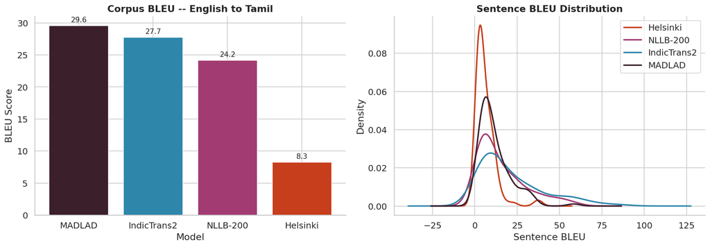

```
Saved plots/parta_bleu_analysis.png
```

```python
# Cell 9 -- VIZ A1: BLEU bar chart + sentence-BLEU KDE
fig, axes = plt.subplots(1, 2, figsize=(14, 5))

# Left -- Corpus BLEU bar
ax = axes[0]
models_sorted = sorted(corpus_bleu_scores, key=corpus_bleu_scores.get, reverse=True)
bars = ax.bar(
    models_sorted,
    [corpus_bleu_scores[m] for m in models_sorted],
    color=[MODEL_COLORS[m] for m in models_sorted],
    edgecolor="white", linewidth=0.8
)
ax.bar_label(bars, fmt="%.1f", padding=3, fontsize=10)
ax.set_title("Corpus BLEU -- English to Tamil", fontweight="bold")
ax.set_ylabel("BLEU Score")
ax.set_xlabel("Model")

# Right -- Sentence BLEU KDE
ax2 = axes[1]
for m in bleu_models:
    df_results[f"bleu_{m}"].plot.kde(
        ax=ax2, label=m, color=MODEL_COLORS[m], linewidth=2
    )
ax2.set_title("Sentence BLEU Distribution", fontweight="bold")
ax2.set_xlabel("Sentence BLEU")
ax2.set_ylabel("Density")
ax2.legend()

plt.tight_layout()
plt.savefig("plots/parta_bleu_analysis.png", bbox_inches="tight")
plt.show()
print("Saved plots/parta_bleu_analysis.png")
```

## 11. Visualization 2: Color-Coded Results Table

The styled table makes it easy to scan which sentences each model handles well. The three-tier color coding follows standard MT quality thresholds:

| Color | BLEU Range | Interpretation |
| --- | --- | --- |
| Green | >= 40 | High quality -- fluent output |
| Yellow | 20 -- 39 | Acceptable -- meaning preserved with errors |
| Red | < 20 | Poor -- significant mistranslation or garbling |

```python
# Cell 10 -- VIZ A2: Color-coded results table
display_cols = (
    ["source_english", "reference_tamil"]
    + [f"pred_{m}" for m in bleu_models]
    + [f"bleu_{m}" for m in bleu_models]
)

def color_bleu(val):
    if val >= 40:   return "background-color: #d4edda; color: #155724"
    elif val >= 20: return "background-color: #fff3cd; color: #856404"
    else:           return "background-color: #f8d7da; color: #721c24"

df_results[display_cols].head(15).style \
    .map(color_bleu, subset=[f"bleu_{m}" for m in bleu_models]) \
    .set_caption("Green (>=40)  |  Yellow (20-40)  |  Red (<20)") \
    .format({f"bleu_{m}": "{:.1f}" for m in bleu_models}) \
    .set_table_styles([{
        "selector": "th",
        "props": [("background-color","#2E86AB"),("color","white")]
    }])
```

Green (>=40) | Yellow (20-40) | Red (<20)

|  | source_english | reference_tamil | pred_Helsinki | pred_NLLB-200 | pred_IndicTrans2 | pred_MADLAD | bleu_Helsinki | bleu_NLLB-200 | bleu_IndicTrans2 | bleu_MADLAD |
| --- | --- | --- | --- | --- | --- | --- | --- | --- | --- | --- |
| 0 | "We now have 4-month-old mice that are non-diabetic that used to be diabetic," he added. | """எங்களிடம் இப்போது 4-மாத-வயதுடைய எலி ஒன்று உள்ளது, முன்னர் அதற்கு நீரிழிவு இருந்தது தற்போது இல்லை"" என்று அவர் மேலும் கூறினார்." | "நமக்கு 4 மாத வயது மூட்டுகள் உள்ளன. | "நாங்கள் இப்போது 4 மாத வயதுடைய எலிகள் உள்ளன, அவை நீரிழிவு நோய் இல்லாதவை, அவை முன்பு நீரிழிவு நோயால் பாதிக்கப்பட்டவை", என்று அவர் மேலும் கூறினார். | "இப்போது எங்களிடம் 4 மாத வயது எலிகள் உள்ளன, அவை நீரிழிவு அல்லாதவை, அவை முன்பு நீரிழிவு நோயாளிகளாக இருந்தன" என்று அவர் மேலும் கூறினார். | "நாங்கள் இப்போது4மாத வயதான சுறாக்களைக் கொண்டுள்ளோம், அவை நீரிழிவு நோய் இல்லாதவை, அவற்றுக்கு நீரிழப்பு இருந்தது," என்று அவர் மேலும் கூறினார். | 0.8 | 17.4 | 21.2 | 20.2 |
| 1 | Dr. Ehud Ur, professor of medicine at Dalhousie University in Halifax, Nova Scotia and chair of the clinical and scientific division of the Canadian Diabetes Association cautioned that the research is… | ஹாலிஃபாக்ஸில் உள்ள டல்ஹெளசி பல்கலைக்கழகத்தின் மருத்துவப் பேராசிரியரும், நோவா ஸ்கோட்டியா மற்றும் கனேடிய நீரிழிவு சங்கத்தின் மருத்துவ மற்றும் அறிவியல் பிரிவின் தலைவருமான டாக்டர் இஹுத் உர், ஆராய்ச்சி இன்… | இந்த ஆராய்ச்சி இன்னும் ஆரம்பத்திலேயே இருக்கிறது என்று கனடா நாட்டு சர்க்கரை வியாதி சங்கத்தின் மருத்துவ மற்றும் அறிவியல் பிரிவின் மருத்துவ நிபுணரான டாக்டர் ஏகூத் யூனிவர்சிட்டி, ஹால்ஃபாக்ஸ், ஹால்ஃபாக்ஸ் … | ஹாலிஃபாக்ஸில் உள்ள டால்ஹூஸி பல்கலைக்கழகத்தில் மருத்துவப் பேராசிரியரும், கனடிய நீரிழிவு நோய் சங்கத்தின் மருத்துவ மற்றும் அறிவியல் பிரிவின் தலைவரும் டாக்டர் எஹுட் உர், இந்த ஆராய்ச்சி இன்னும் ஆரம்ப நாட்க… | நோவா ஸ்கோடியாவின் ஹாலிஃபாக்ஸில் உள்ள டல்ஹெளசி பல்கலைக்கழகத்தின் மருத்துவப் பேராசிரியரும், கனேடிய நீரிழிவு சங்கத்தின் மருத்துவ மற்றும் அறிவியல் பிரிவின் தலைவருமான டாக்டர் எஹுத் உர், ஆராய்ச்சி இன்னும் அ… | ஹாலிஃபாக்ஸ், நோவா ஸ்கோசியாவில் உள்ள டால்ஹவுசி பல்கலைக்கழகத்தில் மருத்துவப் பேராசிரியரும், கனடிய நீரிழிவு சங்கத்தின் மருத்துவ மற்றும் அறிவியல் பிரிவின் தலைவருமான டாக்டர் எஹூட் உர், இந்த ஆராய்ச்சி இன்னு… | 14.6 | 24.1 | 55.1 | 35.0 |
| 2 | Like some other experts, he is skeptical about whether diabetes can be cured, noting that these findings have no relevance to people who already have Type 1 diabetes. | பிற வல்லுனர்கள் போலவே அவரும், ஏற்கனவே டைப் 1 இரத்த சர்க்கரை நோயுள்ளவர்களுக்கு இந்த கண்டுபிடிப்புகள் பொருந்தவில்லை என்பதால் இரத்த சர்க்கரை நோயிற்கு நிவாரணம் உள்ளதா என்பது குறித்து சந்தேகமடைகிறார். | மற்ற சில நிபுணர்களைப் போலவே, சர்க்கரை வியாதி குணமா என்பதை சந்தேகிக்கிறார். | சில நிபுணர்களைப் போலவே, நீரிழிவு நோயை குணப்படுத்த முடியுமா என்று அவர் சந்தேகிக்கிறார், இந்த கண்டுபிடிப்புகள் ஏற்கனவே வகை 1 நீரிழிவு நோயால் பாதிக்கப்பட்டவர்களுக்கு பொருந்தாது என்று குறிப்பிடுகிறார். | மற்ற சில நிபுணர்களைப் போலவே, நீரிழிவு நோயைக் குணப்படுத்த முடியுமா என்பது குறித்து அவருக்கு சந்தேகம் உள்ளது, இந்த கண்டுபிடிப்புகள் ஏற்கனவே வகை 1 நீரிழிவு நோயால் பாதிக்கப்பட்டவர்களுக்கு எந்த தொடர்பும் இ… | மற்ற சில நிபுணர்களைப் போலவே, அவர் நீரிழிவு நோயை குணப்படுத்த முடியுமா என்று சந்தேகிக்கிறார், இந்த கண்டுபிடிப்புகள் ஏற்கனவே வகை 1 நீரிழப்பு உள்ள மக்களுக்கு பொருந்தாது என்று குறிப்பிட்டார். | 1.6 | 4.3 | 4.5 | 4.1 |
| 3 | On Monday, Sara Danius, permanent secretary of the Nobel Committee for Literature at the Swedish Academy, publicly announced during a radio program on Sveriges Radio in Sweden the committee, unable to… | திங்கட் கிழமையன்று ஸ்வீடிஷ் அகேடமியில் இலக்கியத்திற்கான நோபல் குழுவின் செயலாளர், சாரா டேனியஸ் ஸ்வீடனின் ஸ்வெரிஜெஸ் ரேடியோவின் ஒரு ரேடியோ நிகழ்ச்சியில், பாப் டைலன் 2016ஆம் வருட இலக்கியத்திற்கான நோபல் ப… | திங்கட்கிழமை, ஸ்வீடனிலுள்ள ஸ்வீடனிலுள்ள ஸ்வீடனிலுள்ள ரீகெக்ஸஸ் ரேடியோவில் ஒரு ரேடியோ நிகழ்ச்சியின்போது வெளியரங்கமாக அறிவித்தார். | திங்களன்று, ஸ்வீடிஷ் அகாடமியில் இலக்கியத்திற்கான நோபல் குழுவின் நிரந்தர செயலாளர் சாரா டானியஸ், ஸ்வீடனில் உள்ள ஸ்வெர்டிஸ் வானொலி நிகழ்ச்சியின் போது வெளிப்படையாக அறிவித்தார், இந்த குழு, 2016 இலக்கியத்தி… | திங்களன்று, ஸ்வீடிஷ் அகாடமியின் இலக்கியத்திற்கான நோபல் குழுவின் நிரந்தர செயலாளரான சாரா டேனியஸ், ஸ்வீடனில் உள்ள ஸ்வெரிஜஸ் வானொலியில் ஒரு வானொலி நிகழ்ச்சியின் போது பகிரங்கமாக அறிவித்தார், 2016 ஆம் ஆண்டி… | 2016 ஆம் ஆண்டு இலக்கியத்திற்கான நோபல் பரிசு வென்ற பாப் டிலானை நேரடியாகத் தொடர்பு கொள்ள முடியாமல் போனது குறித்து, சுவீடிஷ் அகாதெமியில் இலக்கியத்துக்கான நோபெல் கமிட்டியின் நிரந்தர செயலாளர் சாரா டானியஸ்,… | 1.3 | 5.1 | 5.6 | 5.2 |
| 4 | Danius said, "Right now we are doing nothing. I have called and sent emails to his closest collaborator and received very friendly replies. For now, that is certainly enough." | """இப்போது நாம் ஒன்றும் செய்யவில்லை. நான் அவரது நெருங்கிய கூட்டாளிக்கு அழைப்பு செய்து மின்னஞ்சல்களை அனுப்பி, மிகவும் நட்புடன் பதில்களைப் பெற்றுள்ளேன். இப்போதைக்கு, அது போதுமானது."" என்று டானியஸ் கூறின… | "ஆம், நாங்கள் ஒன்றும் செய்யவில்லை. நான் தொலைபேசிகளை அவருடைய மிக நெருங்கிய துணைவரிடம் அனுப்பியுள்ளேன். மிகவும் சிநேகப்பான்மையான பதில்கள் பெற்றேன். இப்போது அது போதுமானது" என்று கூறினார். | டானியஸ் கூறினார், "இப்போது நாங்கள் எதுவும் செய்யவில்லை. நான் அவரது நெருங்கிய ஒத்துழைப்பாளருக்கு அழைத்து மின்னஞ்சல்களை அனுப்பியுள்ளேன் மற்றும் மிகவும் நட்பான பதில்களைப் பெற்றேன். இப்போதைக்கு, அது நிச்ச… | டேனியஸ் கூறினார், "இப்போது நாங்கள் எதுவும் செய்யவில்லை. நான் அவரது நெருங்கிய ஒத்துழைப்பாளரை அழைத்து மின்னஞ்சல்களை அனுப்பியுள்ளேன், மேலும் மிகவும் நட்பான பதில்களைப் பெற்றுள்ளேன். இப்போதைக்கு, அது நிச்ச… | Danius கூறினார், "இப்போது நாங்கள் எதையும் செய்யவில்லை. நான் அவரது நெருங்கிய உதவியாளர்களை அழைத்து மின்னஞ்சல் அனுப்பினேன் மற்றும் மிகவும் நட்பான பதில்களை பெற்றேன். இப்பொழுது, அது நிச்சயமாக போதுமானது." | 11.4 | 24.3 | 28.1 | 17.3 |
| 5 | Previously, Ring's CEO, Jamie Siminoff, remarked the company started when his doorbell wasn't audible from his shop in his garage. | முன்பு, ரிங்க்ஸின் சீஈஓ ஜேமி ஸிமினாஃப், அவருக்கு அவரது கேரேஜினுள் உள்ள கடைக்குள் கதவு அறிவிப்பு மணியின் ஒலி கேட்காத காரணத்தால், அந்த நிறுவனம் துவங்கப்பட்டது என்பதை குறிப்பிட்டார். | முன்பு, ரிக்ஸின் CEO, ஜேமி சிமினியோஃப், அந்த நிறுவனம் தொடங்கியது அவரது வாயிலில் இருந்து அவரது கடையில் இருந்து ஒரு ஒலி கேட்கவில்லை. | முன்னதாக, ரிங்கின் தலைமை நிர்வாக அதிகாரி, ஜேமி சிமினோஃப், தனது கேரஜில் உள்ள தனது கடையில் இருந்து அவரது கதவு மணி கேட்கப்படாதபோது நிறுவனம் தொடங்கியது என்று குறிப்பிட்டார். | முன்னதாக, ரிங்கின் தலைமை நிர்வாக அதிகாரி ஜேமி சிமினோஃப், தனது கேரேஜில் உள்ள தனது கடையில் இருந்து அவரது கதவு மணி கேட்கப்படாதபோது நிறுவனம் தொடங்கியது என்று குறிப்பிட்டார். | முன்னதாக, ரிங்கின் தலைமை செயல் அதிகாரி, ஜேமி சிமினோஃப், அவரது கார்கரேவில் உள்ள அவரது கடையில் இருந்து அவரது கதவு பெல்லை கேட்க முடியாதபோது நிறுவனம் தொடங்கப்பட்டது என்று குறிப்பிட்டார். | 8.4 | 4.5 | 4.4 | 4.3 |
| 6 | He built a WiFi door bell, he said. | அவர், தான் வைஃபை கதவு அறிவிப்பு மணியை உருவாக்கியதாகக் கூறினார். | அவர் ஒரு WiFi கதவு மணியை கட்டினார், அவர் கூறினார். | அவர் ஒரு வைஃபை கதவு மணி கட்டப்பட்டது, அவர் கூறினார். | அவர் ஒரு வைஃபை கதவு மணியை உருவாக்கினார், என்றார். | அவர் ஒரு Wi-Fi கதவு பெல் கட்டினார், அவர் கூறினார். | 11.0 | 13.1 | 11.2 | 10.6 |
| 7 | Siminoff said sales boosted after his 2013 appearance in a Shark Tank episode where the show panel declined funding the startup. | ஸிமினாஃப், 2013 ஆம் ஆண்டு ஷார் டேங்க் தொடரில் தான் தோன்றியது மற்றும் அவர்கள் தன் ஸ்டார்ட் அப் நிறுவனத்திற்கு பணம் அளிக்க மறுத்ததன் பின்னர் அவரது விற்பனை பெருகியது என்று தெரிவித்தார். | சிமினியோஃப், 2013 - ல் அவர் தோன்றி, ஒரு சுறா விரிகுடாவைச் சேர்ந்தபோது விற்பனைகள் அதிகரித்தன என்று சொன்னார். | ஷார்க் டேங்க் எபிசோடில் 2013 இல் அவர் தோன்றிய பின்னர் விற்பனை அதிகரித்தது என்று சிமினோவ் கூறினார், அங்கு நிகழ்ச்சி குழு ஸ்டார்ட்அப்பை நிதியளிப்பதை மறுத்தது. | 2013 ஆம் ஆண்டு ஷார்க் டேங்க் எபிசோடில் தோன்றிய பின்னர் விற்பனை அதிகரித்ததாக சிமினோஃப் கூறினார், அங்கு நிகழ்ச்சி குழு தொடக்கத்திற்கு நிதியளிக்க மறுத்துவிட்டது. | ஷார்க் டான்க் நிகழ்ச்சியில் தனது 2013 தோற்றத்திற்குப் பிறகு விற்பனை அதிகரித்ததாக சிமினோஃப் கூறினார், அங்கு நிகழ்ச்சி குழுவினர் தொடங்குவதற்கு நிதியுதவி அளிக்க மறுத்தனர். | 3.2 | 2.3 | 6.7 | 2.1 |
| 8 | In late 2017, Siminoff appeared on shopping television channel QVC. | சிமினோஃப் 2017 இன் பிற்பகுதியில், ஷாப்பிங் தொலைக்காட்சி சேனலான QVC இல் தோன்றினார். | 2017 - ன் பிற்பகுதியில், ஸிமினிஃபோ தொலைக்காட்சி அலைவரிசையில் QVC - ல் காட்சியளித்தார். | 2017 ஆம் ஆண்டின் பிற்பகுதியில், சிமினோவ் ஷாப்பிங் தொலைக்காட்சி சேனல் QVC இல் தோன்றினார். | 2017 ஆம் ஆண்டின் பிற்பகுதியில், சிமினோஃப் ஷாப்பிங் தொலைக்காட்சி சேனலான கியூ. வி. சி. யில் தோன்றினார். | 2017 ஆம் ஆண்டின் இறுதியில், சிமினோஃப் ஷாப்பிங் தொலைக்காட்சி அலைவரிசை QVC இல் தோன்றினார். | 8.1 | 26.9 | 12.5 | 25.5 |
| 9 | Ring also settled a lawsuit with competing security company, the ADT Corporation. | ரிங் அதன் போட்டி பாதுகாப்பு நிறுவனமான ADT கார்ப்பரேஷனுடன் உரிமை கோரல் வழக்கை தீர்த்துக் கொண்டது. | அந்த ஏடி கம்ப்யூட்டரில், போட்டியாளர் பாதுகாப்பு நிறுவனம் ஒரு சட்டத்தொகுதியை நிறுவியது. | ரிங் மேலும் போட்டியிடும் பாதுகாப்பு நிறுவனமான ADT கார்ப்பரேஷனுடன் வழக்குத் தீர்த்தது. | போட்டி பாதுகாப்பு நிறுவனமான ஏடிடி கார்ப்பரேஷனுடன் ஒரு வழக்கையும் ரிங் தீர்த்துக் கொண்டார். | ரிங்கின் போட்டி பாதுகாப்பு நிறுவனமான ADT கார்ப்பரேஷனுடன் ஒரு வழக்கையும் தீர்த்து வைத்தது. | 3.7 | 21.5 | 14.4 | 30.6 |
| 10 | While one experimental vaccine appears able to reduce Ebola mortality, up until now, no drugs have been clearly demonstrated suitable for treating existing infection. | எபோலாவினால் ஏற்படும் உயிரிழப்புகளைக் குறைக்கும் என நம்பப்படும் ஒரே ஒரு சோதனை தடுப்பூசியைத் தவிர, வேறு எந்த மருந்தும் தற்போதுள்ள தொற்றிற்கு ஏற்ப சிகிச்சை அளிப்பவையாக செயல்படவில்லை. | ஒரு பரிசோதனை தடுப்பூசி மருந்து எலக்ட்ரானிக் சாவைக் குறைப்பதாகத் தெரிகிறது. | ஒரு பரிசோதனை தடுப்பூசி எபோலா நோய்த்தொற்றின் இறப்பைக் குறைக்கக்கூடியதாகத் தோன்றுகிறது என்றாலும், இதுவரை, தற்போதுள்ள நோய்த்தொற்றுக்கு சிகிச்சையளிக்க ஏற்ற மருந்துகள் எதுவும் தெளிவாக நிரூபிக்கப்படவில்லை. | ஒரு சோதனை தடுப்பூசி எபோலா இறப்பைக் குறைக்க முடியும் என்று தோன்றினாலும், இப்போது வரை, தற்போதுள்ள நோய்த்தொற்றுக்கு சிகிச்சையளிக்க பொருத்தமான மருந்துகள் எதுவும் தெளிவாக நிரூபிக்கப்படவில்லை. | ஒரு பரிசோதனை தடுப்பூசி எபோலா மரணத்தை குறைக்க முடியும் என்று தோன்றுகிறது, ஆனால் இதுவரை, எந்த மருந்துகளும் ஏற்கனவே உள்ள தொற்றுக்கு சிகிச்சையளிப்பதற்கு ஏற்றதாக தெளிவாக நிரூபிக்கப்படவில்லை. | 1.3 | 2.4 | 4.3 | 2.3 |
| 11 | One antibody cocktail, ZMapp, initially showed promise in the field, but formal studies indicated it had less benefit than sought in preventing death. | எதிர்ப்புசக்திக் கொண்ட சிற்றுண்டி, ZMapp, ஆரம்பத்தில் இந்தத் துறையில் நம்பிக்கைக் கொடுத்தது, ஆனால் முறைப்படி செய்யப்பட்ட ஆய்வுகள் இது மரணத்தை தடுப்பதற்கான வழிகளுக்குப் பதிலாக குறைவான நன்மையே தருகிறது … | ஆனால், மரணத்தைத் தடுப்பதற்கு முயற்சி செய்வது மட்டுமே போதுமானதாக இல்லை என்பதை முறைப்படியான ஆராய்ச்சிகள் சுட்டிக்காட்டின. | ZMapp என்ற ஒரு ஆன்டிபாடி காக்டெய்ல் ஆரம்பத்தில் இந்த துறையில் நம்பிக்கைக்குரியதாக இருந்தது, ஆனால் முறையான ஆய்வுகள் மரணத்தைத் தடுக்க முயன்றதை விட குறைவான நன்மைகளைக் கொண்டிருந்ததாகக் காட்டியது. | ஒரு ஆன்டிபாடி காக்டெய்ல், ZMapp, ஆரம்பத்தில் இந்தத் துறையில் நம்பிக்கையைக் காட்டியது, ஆனால் முறையான ஆய்வுகள் மரணத்தைத் தடுப்பதில் விரும்பியதை விட குறைவான நன்மையைக் கொண்டிருந்தன என்பதைக் குறிக்கின்றன. | ஒரு எதிர்ப்பொருள் கலவையானது, ZMapp, ஆரம்பத்தில் இந்த துறையில் வாக்குறுதியைக் காட்டியது, ஆனால் முறையான ஆய்வுகள் மரணத்தைத் தடுப்பதில் இது தேடப்பட்டதை விட குறைவான நன்மைகளைக் கொண்டிருப்பதைக் காட்டின. | 1.5 | 3.9 | 21.3 | 13.0 |
| 12 | In the PALM trial, ZMapp served as a control, meaning scientists used it as a baseline and compared the three other treatments to it. | PALM சோதனையில், ZMapp ஒரு கட்டுப்பாடாகச் செயல்பட்டது, அதாவது விஞ்ஞானிகள் இதை ஒரு அடிப்படையாகப் பயன்படுத்தினர் மற்றும் அதனுடன் மற்ற மூன்று சிகிச்சையையும் ஒப்பிட்டனர். | ஸாம்பாக் என்ற அறிவியல் அறிஞர்கள் அதை ஒரு அடிவானமாக உபயோகித்து, மற்ற மூன்று சிகிச்சைகளை அதற்கு ஒப்பிட்டனர். | PALM சோதனையில், ZMapp ஒரு கட்டுப்பாடாக இருந்தது, அதாவது விஞ்ஞானிகள் அதை ஒரு அடிப்படை அடிப்படையாகப் பயன்படுத்தி மற்ற மூன்று சிகிச்சைகளையும் அதனுடன் ஒப்பிட்டுப் பார்த்தனர். | PALM சோதனையில், ZMapp ஒரு கட்டுப்பாட்டாக செயல்பட்டது, அதாவது விஞ்ஞானிகள் அதை ஒரு அடிப்படையாகப் பயன்படுத்தினர் மற்றும் மற்ற மூன்று சிகிச்சைகளை அதனுடன் ஒப்பிட்டனர். | PALM சோதனையில், ZMapp ஒரு கட்டுப்பாட்டாக செயல்பட்டது, அதாவது விஞ்ஞானிகள் அதை அடிப்படையாகக் கொண்டு மற்ற மூன்று சிகிச்சைகளையும் ஒப்பிட்டுப் பார்த்தனர். | 5.5 | 25.9 | 45.3 | 31.7 |
| 13 | USA Gymnastics supports the United States Olympic Committee's letter and accepts the absolute need of the Olympic family to promote a safe environment for all of our athletes. | USA ஜிம்னாஸ்டிக்ஸ், யுனைடெட் ஸ்டேட்ஸ் ஒலிம்பிக் கமிட்டியின் கடிதத்தை ஆதரிக்கிறது மற்றும் விளையாட்டு வீரர்கள் அனைவருக்கும் பாதுகாப்பான சூழலை ஊக்குவிக்க ஒலிம்பிக் குடும்பத்தின் முழுமையான தேவையை ஏற்றுக்க… | US ஜிம்மண்டிஸ் அமெரிக்க ஒலிம்பிக் கமிட்டியின் கடிதத்தை ஆதரிக்கிறது மற்றும் ஒலிம்பிக் குடும்பத்தின் முழு தேவையை ஏற்று எங்கள் விளையாட்டு வீரர்கள் அனைவருக்கும் பாதுகாப்பான சூழலை முன்னேற்றுவிக்க. | யு.எஸ்.ஏ ஜிம்னாஸ்டிக்ஸ் அமெரிக்க ஒலிம்பிக் கமிட்டியின் கடிதத்தை ஆதரிக்கிறது மற்றும் ஒலிம்பிக் குடும்பத்தின் முழுமையான தேவையை ஏற்றுக்கொள்கிறது அனைத்து விளையாட்டு வீரர்களுக்கும் பாதுகாப்பான சூழலை ஊக்குவ… | அமெரிக்க ஜிம்னாஸ்டிக்ஸ் அமெரிக்க ஒலிம்பிக் கமிட்டியின் கடிதத்தை ஆதரிக்கிறது மற்றும் நமது அனைத்து விளையாட்டு வீரர்களுக்கும் பாதுகாப்பான சூழலை ஊக்குவிக்க ஒலிம்பிக் குடும்பத்தின் முழுமையான தேவையை ஏற்றுக்… | ஐக்கிய அமெரிக்க ஜிம்னாஸ்டிக்ஸ் சங்கம் ஐரோப்பிய ஒலிம்பிக் கமிட்டியின் கடிதத்திற்கு ஆதரவு அளிக்கிறது, மேலும் நமது விளையாட்டு வீரர்கள் அனைவருக்கும் பாதுகாப்பான சூழலை உருவாக்க வேண்டும் என்ற ஒலிம்பிக் குடு… | 36.3 | 36.4 | 54.5 | 22.4 |
| 14 | We agree with the USOC's statement that the interests of our athletes and clubs, and their sport, may be better served by moving forward with meaningful change within our organization, rather than dec… | எங்களுடைய விளையாட்டு வீரர்கள் மற்றும் கிளப்புகளின் நலன்கள், மற்றும் அவர்களின் விளையாட்டு ஆகியவை தீர்மானிப்பதை விட, எங்கள் நிறுவனத்திற்குள் அர்த்தமுள்ள மாற்றத்துடன் முன்னேறுவதன் மூலம் சிறப்பாக சேவை செய… | USOC வின் கூற்றை நாம் ஒத்துக்கொள்வோம் எங்கள் விளையாட்டு வீரர்கள் மற்றும் க்ளாஸ் மற்றும் அவர்களுடைய விளையாட்டுகள், நம்முடைய அமைப்பில் அர்த்தமுள்ள மாற்றத்துடன் முன்னேறுவது நல்லது. | எங்கள் விளையாட்டு வீரர்கள் மற்றும் கிளப்புகளின் நலன்களுக்கும், அவர்களின் விளையாட்டுக்கும், சான்றிதழ் நீக்கப்படுவதற்குப் பதிலாக, எங்கள் அமைப்பில் அர்த்தமுள்ள மாற்றத்துடன் முன்னேறிச் செல்வதன் மூலம் சிறப… | எங்கள் விளையாட்டு வீரர்கள் மற்றும் கிளப்புகளின் நலன்கள் மற்றும் அவர்களின் விளையாட்டு, எங்கள் நிறுவனத்திற்குள் அர்த்தமுள்ள மாற்றத்துடன் முன்னேறுவதன் மூலம் சிறப்பாக செயல்பட முடியும் என்ற யு. எஸ். ஓ. சிய… | நமது விளையாட்டு வீரர்கள் மற்றும் கழகங்களின் நலன்கள் மற்றும் விளையாட்டு, நமது அமைப்பின் உள்ளே அர்த்தமுள்ள மாற்றங்களை முன்னெடுத்துச் செல்வதன் மூலம், சான்றிதழ் ரத்து செய்வதை விட சிறந்த முறையில் சேவை செய்… | 6.4 | 17.4 | 38.9 | 5.5 |

## 12. Qualitative Error Analysis

The table below is filled after the run completes. It captures sentence-level observations that corpus BLEU cannot reveal -- script fidelity, handling of proper nouns, and morphological accuracy.

[output not shown]